# matplotlib homework

1. Make a plot of a straight line. Use `linspace()` to create the *x* values and the formula of a straight line, *y = a + b*x*, to create the* y* values (use an *a* and *b* of your choosing). You can pretend x and y are anything you like (x = time, y = international piracy or whatever).

```python
import numpy as np
import matplotlib.pyplot as plt
```

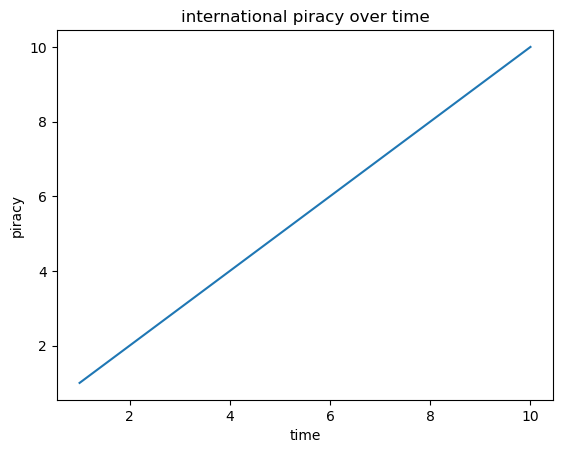

```python
x = np.linspace(1,10)
plt.plot(x,x)
plt.title('international piracy over time')
plt.xlabel('time')
plt.ylabel('piracy')
```

2. Make some data that are straight line values from the same straight line relationship as in 1. plus random noise. Plot these data.

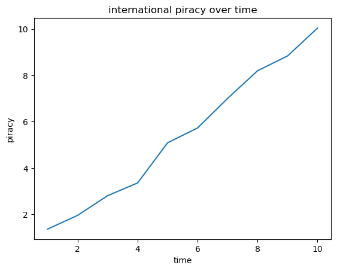

```python
x2 = [1,2,3,4,5,6,7,8,9,10]
y2 = x2 + 0.25*np.random.randn(len(x2))

plt.plot(x2,y2)
plt.title('international piracy over time')
plt.xlabel('time')
plt.ylabel('piracy')
```

3. Plot the straight line from 1. and the data from 2. on the same graph. Make sure to add the standard annotations, including a legend.

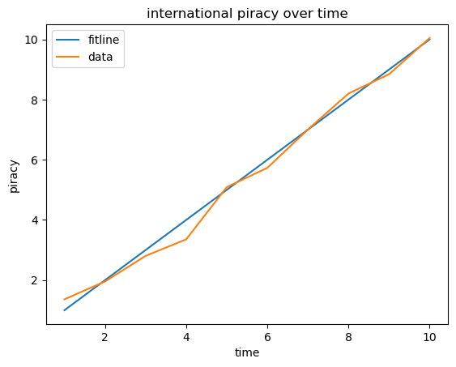

```python
plt.plot(x,x, label = 'fitline')
plt.plot(x2,y2, label = 'data')

plt.title('international piracy over time')
plt.xlabel('time')
plt.ylabel('piracy')
plt.legend()
```

4. Tinker around with your plot (colors, symbols, marker sizes, etc.) until you have a plot you would be happy to use in a presentation.

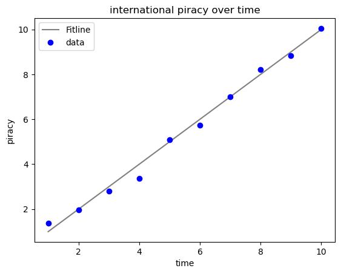

```python
plt.plot(x,x, label = 'Fitline', color = 'k', alpha = 0.5)
plt.plot(x2,y2, 'bo', label = 'data')

plt.title('international piracy over time')
plt.xlabel('time')
plt.ylabel('piracy')
plt.legend()
```

5. Make 500 ***normally*** distributed random numbers and make a histogram of them.

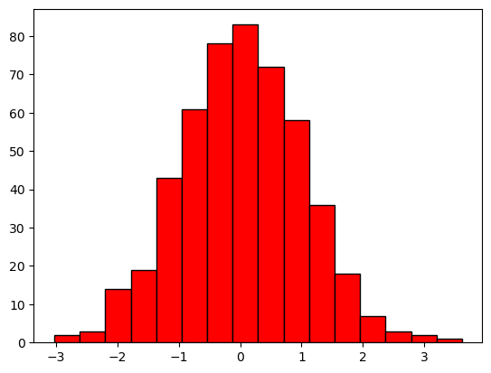

```python
data = np.random.randn(500)

plt.hist(data, bins = 16, color = 'r', edgecolor = 'k');
```

6. Make 500 ***uniformly*** distributed random numbers (use `...rand()` instead of `...randn()`) and make a histogram of them.

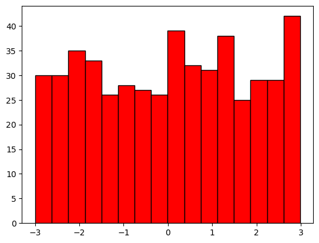

```python
data2 = 6 * np.random.rand(500) - 3

plt.hist(data2, bins = 16, color = 'r', edgecolor = 'k');
```

7. Plot the histograms from 5. and 6. in the same axes to compare the two distributions. Tinker around with the `color =` and `alpha =` arguments to `plt.hist()` until you're happy with your figure. Don't forget the axis labels and a legend!

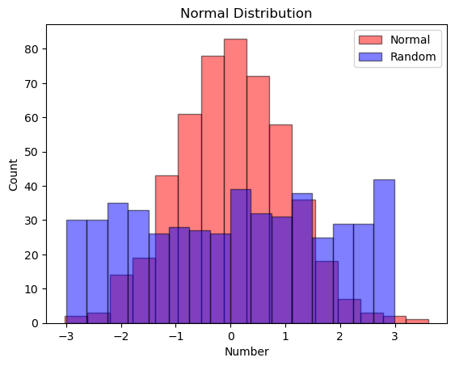

```python
plt.hist(data, bins = 16, color = 'r', edgecolor = 'k', alpha = 0.5, label = 'Normal');
plt.hist(data2, bins = 16, color = 'b', edgecolor = 'k', alpha = 0.5, label = 'Random');


plt.title('Normal Distribution')
plt.xlabel('Number')
plt.ylabel('Count')
plt.legend()
```

8. Make a figure with 3 subplots, the first containing the plot of the data with a straight line (from 3.), and the second and third containing each of the 2 histograms created in 5. and 6. Try a 3x1 and 1x3 layout and show your favorite.

[figure not shown]

```python
#decided to use a 3x2 layout as to prefent the amount of stretch distortion, alligning them in a column

plt.subplot(3,2,1)
plt.plot(x,x, label = 'fitline')
plt.plot(x2,y2, label = 'data')

plt.title('international piracy over time')
plt.xlabel('time')
plt.ylabel('piracy')
plt.legend()

plt.subplot(3,2,3)
plt.hist(data, bins = 16, color = 'r', edgecolor = 'k');
plt.title('Normal Distribution')
plt.xlabel('Number')
plt.ylabel('Count')
plt.subplot(3,2,5)

plt.hist(data2, bins = 16, color = 'b', edgecolor = 'k');
plt.title('Random Distribution')
plt.xlabel('Number')
plt.ylabel('Count')
```